# Medicaid Provider Spending

Earl F Glynn watchdoglab.substack.com/

2026-02-13

[`HHS//OPENDATA`](https://opendata.hhs.gov/datasets/medicaid-provider-spending/)

Provider-level Medicaid spending data from T-MSIS, aggregated by billing or servicing provider, procedure code, and month. Covers fee-for-service, managed care, and CHIP claims from 2018-2024.

This dataset contains provider-level Medicaid spending data aggregated from outpatient and professional claims with valid HCPCS codes, covering January 2018 through December 2024. It provides insights into how Medicaid dollars are distributed across providers and procedures nationwide.

# 1 Setup

## 1.1

## 1.2 Constants

```r
EXCEL_LIMIT <- 2^20
```

```r
plotCaptionLeft  <- "HHS//OPEN DATA"
plotCaptionRight <- paste("watchdoglab.substack.com", format(Sys.time(), "%Y-%m-%d"))
```

## 1.3 Packages

```r
library(tidyverse)
```

```r
library(lubridate)
```

Display formatting

```r
library(kableExtra)  # kable_styling
```

I/O

```r
library(readxl)      # read_xlsx
```

```r
library(readr)       # write_csv
library(writexl)     # write_xlsx
```

Graphics

```r
library(scales)      # comma, comma_format
```

Utilities

```r
library(downloader)  # download
```

```r
library(tools)       # md5sum
```

## 1.4 ggplot theme

[ggplot Themes Gallery](https://www.datanovia.com/en/blog/ggplot-themes-gallery/)

```r
theme_set(theme_minimal() +

          theme(axis.text             = element_text(size = 10),
                axis.title            = element_text(size = 14),

                legend.position       = "bottom",

                plot.caption          = element_text(hjust = c(0.0,1.0),
                                                     size = 10),
                plot.caption.position = "plot",

                plot.title.position   = "plot",

                strip.background      = element_rect(fill = "aliceblue"),
                strip.text            = element_text(size = 14),

                title                 = element_text(size = 14)))
```

```r
COLOR_BAR     <- "skyblue"
COLOR_OUTLINE <- "grey80"
```

## 1.5 Helper functions

```r
Show <- function(data, caption="", bigMark="",
                 height = NULL, width = NULL, ...)
{
  data                                       |>
  kable("html", caption=caption,
        format.args=list(big.mark=bigMark))  |>
  kable_styling(bootstrap_options=c("striped", "bordered", "condensed"),
                position="left",
                full_width=FALSE, ...)       |>
  scroll_box(height = height, width = width)
}
```

# 2 Read Medicaid Provider Spending data

```r
spending <- read_csv("medicaid-provider-spending.csv", col_types = "cccciid")
nrow(spending)
```

```
[1] 227083361
```

```r
glimpse(spending)
```

```
Rows: 227,083,361
Columns: 7
$ BILLING_PROVIDER_NPI_NUM   <chr> "1376609297", "1376609297", "1376609297", "…
$ SERVICING_PROVIDER_NPI_NUM <chr> "1376609297", "1376609297", "1376609297", "…
$ HCPCS_CODE                 <chr> "T1019", "T1019", "T1019", "T1019", "T1019"…
$ CLAIM_FROM_MONTH           <chr> "2024-07", "2024-08", "2024-05", "2024-06",…
$ TOTAL_UNIQUE_BENEFICIARIES <int> 39765, 39677, 39678, 39834, 39527, 35011, 3…
$ TOTAL_CLAIMS               <int> 1205701, 1152534, 1157235, 1164582, 1099808…
$ TOTAL_PAID                 <dbl> 118887675, 115561066, 112823255, 111449173,…
```

# 3 Overall summary stats

```r
options(scipen = 999)
spendingStats <-
  spending    |>
  summarize(
             Records              = n(),
            `Billing Providers`   = n_distinct(BILLING_PROVIDER_NPI_NUM, na.rm = TRUE),
            `Servicing Providers` = n_distinct(SERVICING_PROVIDER_NPI_NUM, na.rm = TRUE),
            `HCPCS Codes`         = n_distinct(HCPCS_CODE, na.rm = TRUE),

            `First Month`         = min(CLAIM_FROM_MONTH,  na.rm = TRUE),
            `Last Month`          = max(CLAIM_FROM_MONTH,  na.rm = TRUE),

            `Low Beneficiaries`   = min(TOTAL_UNIQUE_BENEFICIARIES, na.rm = TRUE),
            `High Beneficiaries`  = max(TOTAL_UNIQUE_BENEFICIARIES, na.rm = TRUE),

            `Low Claims`          = min(TOTAL_CLAIMS, na.rm = TRUE),
            `High Claims`         = max(TOTAL_CLAIMS, na.rm = TRUE),
            `Total Claims`        = sum(TOTAL_CLAIMS, na.rm = TRUE),

            `Low Paid`            = min(TOTAL_PAID, na.rm = TRUE),
            `High Paid`           = max(TOTAL_PAID, na.rm = TRUE),
            `Total Paid`          = sum(TOTAL_PAID, na.rm = TRUE)
           )

spendingStats |> Show(bigMark = ",")
```

| Records | Billing Providers | Servicing Providers | HCPCS Codes | First Month | Last Month | Low Beneficiaries | High Beneficiaries | Low Claims | High Claims | Total Claims | Low Paid | High Paid | Total Paid |
| --- | --- | --- | --- | --- | --- | --- | --- | --- | --- | --- | --- | --- | --- |
| 227,083,361 | 617,503 | 1,627,362 | 10,881 | 2018-01 | 2024-12 | 12 | 159,423 | 12 | 1,607,071 | 18,825,564,012 | -183,021.8 | 118,887,675 | 1,093,562,833,512 |

```r
write_xlsx(spendingStats, "First-Look-Medicaid-Provider-Spending-Overall-Stats.xlsx")
```

# 4 Stats by HCPCS_CODE

```r
HCPCSstats <-
  spending |>
  group_by(HCPCS_CODE)            |>
  summarize(
             Records              = n(),
            `Billing Providers`   = n_distinct(BILLING_PROVIDER_NPI_NUM, na.rm = TRUE),
            `Servicing Providers` = n_distinct(SERVICING_PROVIDER_NPI_NUM, na.rm = TRUE),

            `First Month`         = min(CLAIM_FROM_MONTH,  na.rm = TRUE),
            `Last Month`          = max(CLAIM_FROM_MONTH,  na.rm = TRUE),

            `Low Beneficiaries`   = min(TOTAL_UNIQUE_BENEFICIARIES, na.rm = TRUE),
            `High Beneficiaries`  = max(TOTAL_UNIQUE_BENEFICIARIES, na.rm = TRUE),

            `Low Claims`          = min(TOTAL_CLAIMS, na.rm = TRUE),
            `High Claims`         = max(TOTAL_CLAIMS, na.rm = TRUE),
            `Total Claims`        = sum(TOTAL_CLAIMS, na.rm = TRUE),

            `Low Paid`            = min(TOTAL_PAID, na.rm = TRUE),
            `High Paid`           = max(TOTAL_PAID, na.rm = TRUE),
            `Total Paid`          = sum(TOTAL_PAID, na.rm = TRUE)
           )

nrow(HCPCSstats)
```

```
[1] 10881
```

## 4.1 Text for HCPCS_CODEs

A [`List of CPT/HCPCS Codes` is online at CMS.gov](https://www.cms.gov/medicare/coding-billing/healthcare-common-procedure-system/quarterly-update).

I grabbed the `hcpc2026_jan_anweb_01122026.zip` file and extracted `HCPC2026_JAN_ANWEB_01122026.xlsx` for use here.

## 4.2 Add descriptions to stats

```r
HCPCScodes <-
  read_xlsx("HCPC2026_JAN_ANWEB_01122026.xlsx",
            guess_max = EXCEL_LIMIT) |>
  select(HCPC, `SHORT DESCRIPTION`, `LONG DESCRIPTION`)
```

Unclear why fewer codes found in the “master list” than in the data file.

```r
glimpse(HCPCScodes)
```

```
Rows: 9,006
Columns: 3
$ HCPC                <chr> "A1", "A2", "A3", "A4", "A5", "A6", "A7", "A8", "A…
$ `SHORT DESCRIPTION` <chr> "Dressing for one wound", "Dressing for two wounds…
$ `LONG DESCRIPTION`  <chr> "Dressing for one wound", "Dressing for two wounds…
```

```r
HCPCSstats <-
  HCPCSstats |>
  left_join(HCPCScodes, by = c("HCPCS_CODE" = "HCPC")) |>
  relocate(`SHORT DESCRIPTION`, `LONG DESCRIPTION`, .after = HCPCS_CODE) |>
  arrange(-`Total Paid`)
```

## 4.3 Top 25 HCPCS Codes

```r
HCPCSstats |>
  arrange(-`Total Paid`)  |>
  head(25)                |>
  Show(bigMark = ",")
```

| HCPCS_CODE | SHORT DESCRIPTION | LONG DESCRIPTION | Records | Billing Providers | Servicing Providers | First Month | Last Month | Low Beneficiaries | High Beneficiaries | Low Claims | High Claims | Total Claims | Low Paid | High Paid | Total Paid |
| --- | --- | --- | --- | --- | --- | --- | --- | --- | --- | --- | --- | --- | --- | --- | --- |
| T1019 | Personal care ser per 15 min | Personal care services, per 15 minutes, not for an inpatient or resident of a hospital, nursing facility, icf/mr or imd, part of the individualized plan of treatment (code may not be used to identify … | 457,916 | 9,780 | 7,964 | 2018-01 | 2024-12 | 12 | 39,834 | 12 | 1,218,388 | 1,100,608,370 | 0.00 | 118,887,675 | 122,739,547,514 |
| T1015 | Clinic service | Clinic visit/encounter, all-inclusive | 2,429,393 | 13,829 | 78,845 | 2018-01 | 2024-12 | 12 | 14,483 | 12 | 35,484 | 322,233,922 | -183,021.84 | 6,799,595 | 49,152,668,633 |
| T2016 | Habil res waiver per diem | Habilitation, residential, waiver; per diem | 81,288 | 1,761 | 1,474 | 2018-01 | 2024-12 | 12 | 1,540 | 12 | 30,648 | 69,000,080 | 0.00 | 20,567,274 | 34,904,936,746 |
| 99213 | NA | NA | 13,566,914 | 164,075 | 494,093 | 2018-01 | 2024-12 | 12 | 46,484 | 12 | 50,927 | 764,306,590 | -1,728.56 | 5,543,154 | 33,002,827,264 |
| S5125 | Attendant care service /15m | Attendant care services; per 15 minutes | 214,380 | 4,555 | 3,142 | 2018-01 | 2024-12 | 12 | 11,482 | 12 | 248,199 | 398,071,209 | 0.00 | 15,052,478 | 31,342,185,586 |
| 99214 | NA | NA | 11,728,025 | 150,306 | 472,260 | 2018-01 | 2024-12 | 12 | 24,369 | 12 | 26,132 | 502,480,931 | -3,531.11 | 3,124,919 | 29,913,857,938 |
| 99284 | NA | NA | 3,980,198 | 21,452 | 96,400 | 2018-01 | 2024-12 | 12 | 7,007 | 12 | 7,751 | 170,705,529 | -636.92 | 2,080,603 | 20,151,783,534 |
| H2016 | Comp comm supp svc, per diem | Comprehensive community support services, per diem | 72,289 | 2,115 | 1,806 | 2018-01 | 2024-12 | 12 | 4,208 | 12 | 37,571 | 60,739,036 | 0.00 | 27,633,344 | 19,747,791,725 |
| 99283 | NA | NA | 3,270,001 | 20,157 | 94,006 | 2018-01 | 2024-12 | 12 | 7,388 | 12 | 11,336 | 157,926,994 | -368.19 | 2,287,888 | 16,874,996,866 |
| H2015 | Comp comm supp svc, 15 min | Comprehensive community support services, per 15 minutes | 272,463 | 3,908 | 11,626 | 2018-01 | 2024-12 | 12 | 3,929 | 12 | 46,808 | 109,877,296 | 0.00 | 26,579,242 | 16,470,573,873 |
| 99285 | NA | NA | 2,901,462 | 17,705 | 80,590 | 2018-01 | 2024-12 | 12 | 4,609 | 12 | 5,099 | 111,002,396 | -399.17 | 1,970,465 | 15,097,200,452 |
| 90837 | NA | NA | 1,869,501 | 44,034 | 97,821 | 2018-01 | 2024-12 | 12 | 4,586 | 12 | 11,768 | 127,195,989 | -255.75 | 1,639,456 | 12,067,590,643 |
| S5102 | Adult day care per diem | Day care services, adult; per diem | 96,905 | 2,146 | 2,214 | 2018-01 | 2024-12 | 12 | 2,466 | 12 | 28,919 | 111,095,812 | 0.00 | 1,408,722 | 9,340,779,714 |
| 90834 | NA | NA | 1,212,542 | 27,908 | 70,151 | 2018-01 | 2024-12 | 12 | 7,174 | 12 | 18,852 | 108,817,687 | -2,521.90 | 2,402,166 | 8,821,622,006 |
| T2021 | Day habil waiver per 15 min | Day habilitation, waiver; per 15 minutes | 110,852 | 2,363 | 2,599 | 2018-01 | 2024-12 | 12 | 2,667 | 12 | 61,901 | 55,550,230 | 0.00 | 4,200,279 | 8,653,524,975 |
| H2017 | Psysoc rehab svc, per 15 min | Psychosocial rehabilitation services, per 15 minutes | 292,828 | 4,499 | 14,246 | 2018-01 | 2024-12 | 12 | 2,438 | 12 | 59,103 | 78,677,933 | -24,790.51 | 4,183,997 | 8,540,416,259 |
| T1017 | Targeted case management | Targeted case management, each 15 minutes | 283,832 | 4,498 | 9,922 | 2018-01 | 2024-12 | 12 | 14,984 | 12 | 127,779 | 75,144,121 | -4,404.23 | 6,041,039 | 8,423,668,163 |
| T1020 | Personal care ser per diem | Personal care services, per diem, not for an inpatient or resident of a hospital, nursing facility, icf/mr or imd, part of the individualized plan of treatment (code may not be used to identify servic… | 39,648 | 1,038 | 1,036 | 2018-01 | 2024-12 | 12 | 24,809 | 12 | 37,517 | 33,504,642 | 0.00 | 3,482,784 | 8,212,560,786 |
| 90999 | NA | NA | 250,573 | 4,989 | 5,373 | 2018-01 | 2024-12 | 12 | 464 | 12 | 6,555 | 90,103,258 | -81.73 | 3,887,073 | 7,739,248,803 |
| A0427 | Als1-emergency | Ambulance service, advanced life support, emergency transport, level 1 (als 1 - emergency) | 293,550 | 5,789 | 5,648 | 2018-01 | 2024-12 | 12 | 7,060 | 12 | 10,640 | 33,489,615 | -2,760.29 | 22,446,435 | 7,674,558,268 |
| 92507 | NA | NA | 945,764 | 16,583 | 39,075 | 2018-01 | 2024-12 | 12 | 4,438 | 12 | 44,617 | 129,458,330 | 0.00 | 1,327,881 | 7,484,161,290 |
| H2019 | Ther behav svc, per 15 min | Therapeutic behavioral services, per 15 minutes | 481,861 | 5,661 | 28,557 | 2018-01 | 2024-12 | 12 | 3,630 | 12 | 34,760 | 69,547,577 | 0.00 | 5,345,790 | 7,466,162,701 |
| T2033 | Res, nos waiver per diem | Residential care, not otherwise specified (nos), waiver; per diem | 25,005 | 716 | 665 | 2018-01 | 2024-12 | 12 | 2,360 | 12 | 83,980 | 16,562,508 | 0.00 | 20,312,445 | 7,422,419,482 |
| T1000 | Private duty/independent nsg | Private duty / independent nursing service(s) - licensed, up to 15 minutes | 22,131 | 489 | 338 | 2018-01 | 2024-12 | 12 | 1,079 | 12 | 28,870 | 16,800,136 | 0.00 | 17,798,702 | 7,014,566,029 |
| H2014 | Skills train and dev, 15 min | Skills training and development, per 15 minutes | 131,724 | 3,858 | 6,403 | 2018-01 | 2024-12 | 12 | 5,302 | 12 | 45,264 | 60,726,091 | -9,396.24 | 11,182,409 | 6,759,118,319 |

Write full list by HCPCS code to Excel file.

```r
write_xlsx(HCPCSstats, "First-Look-Medicaid-Provider-ByHCPCS-stats.xlsx")
```

# 5 Distribution of `TOTAL PAID`

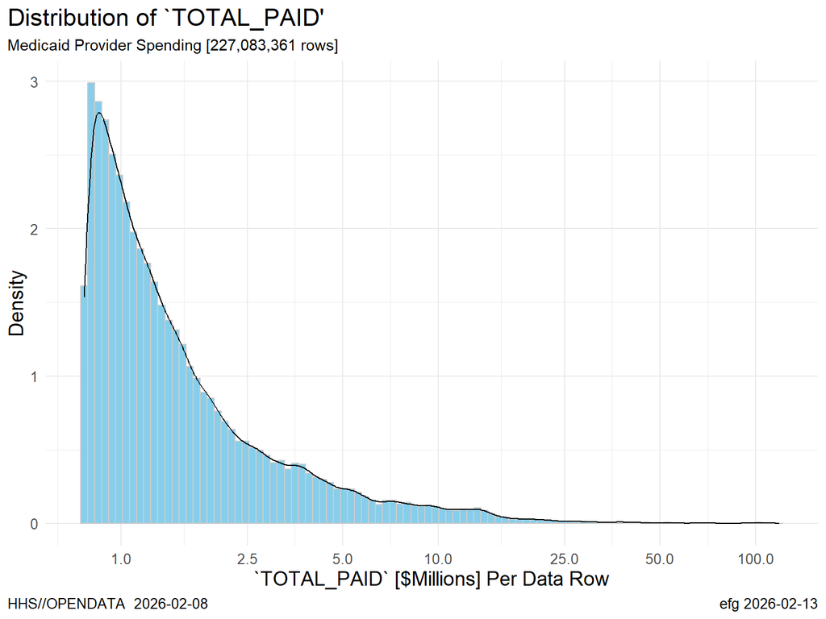

```r
ggplot(spending     |>
       mutate(
           millions = TOTAL_PAID / 1E6,
         )          |>
       head(100000),
       aes(x = millions, y=..density..))                                       +
  geom_histogram(fill = COLOR_BAR, colour = COLOR_OUTLINE, bins=100)           +
  geom_density()                                                               +
  scale_x_log10(breaks=c(0.5, 1, 2.5, 5, 10, 25, 50, 100))   +
  labs(
        title=paste0("Distribution of `TOTAL_PAID'"),
        subtitle = paste0("Medicaid Provider Spending [",
                          comma(nrow(spending)),
                          " rows]"),
        x = "`TOTAL_PAID` [$Millions] Per Data Row",
        y = "Density",
        caption = c(
                     "HHS//OPENDATA  2026-02-08",
                     paste("efg", format(time.1, "%Y-%m-%d"))
                   )
      )
```

# 6 Next step

[Download the latest NPI files](https://download.cms.gov/nppes/NPI_Files.html).

The version 2 file is “new and improved” and have some wider field limits.

The NPI numbers can be used to identify state and address information for the providers and suppliers.

# 7 Epilog

## 7.1

Processing time: 347.2 secs

2026-02-13 2333